# MLM Project 5

Jemar Bather & Zarni Htet [with Martha Moreno, Sarah Rosenbach, James Wu]

```r
#library(readr)
dat <- read.csv("../classroom.csv")
cc.data <- dat[(complete.cases(dat)),]
```

*we have two models to consider, but we first focus on the simpler one:

```r
attach(cc.data)
cc.data$math1st <- mathkind + mathgain
```

$$MATH1ST_{ijk} = b_0 + b_1HOUSEPOV_{k} + b_2YEARSTEA_{jk} + b_3MATHPREP_{jk} + b_4MATHKNOW_{jk} + b_5SES_{ijk} + b_6SEX_{ijk} + b_7MINORITY_{ijk} + \eta_{jk} + \zeta_{k} + \varepsilon_{ijk}$$
With $\zeta_{k}$ ~ N(0,$\sigma^2_{\zeta}$), $\eta_{jk}$ ~ N(0,$\sigma^2_{\eta}$), and $\varepsilon_{ijk}$ ~ N(0,$\sigma^2_{\varepsilon}$), independent of one another.

```r
require(lme4)
require(lmerTest)
#options(digits = 5)
fit1 <- lmer(math1st ~ housepov + yearstea + mathprep + mathknow + ses + sex + minority + (1|schoolid/classid), data=cc.data)
summary(fit1)
```

```
Linear mixed model fit by REML
t-tests use  Satterthwaite approximations to degrees of freedom ['lmerMod']
Formula: math1st ~ housepov + yearstea + mathprep + mathknow + ses + sex +      minority + (1 | schoolid/classid)
   Data: cc.data

REML criterion at convergence: 10729.5

Scaled residuals:
    Min      1Q  Median      3Q     Max
-3.8580 -0.6134 -0.0321  0.5971  3.6598

Random effects:
 Groups           Name        Variance Std.Dev.
 classid:schoolid (Intercept)   93.89   9.69
 schoolid         (Intercept)  169.45  13.02
 Residual                     1064.95  32.63
Number of obs: 1081, groups:  classid:schoolid, 285; schoolid, 105

Fixed effects:
              Estimate Std. Error         df t value Pr(>|t|)
(Intercept)  539.63042    5.31210  275.40000 101.585  < 2e-16 ***
housepov     -17.64847   13.21757  113.90000  -1.335    0.184
yearstea       0.01129    0.14141  226.80000   0.080    0.936
mathprep      -0.27705    1.37583  205.30000  -0.201    0.841
mathknow       1.35004    1.39168  234.50000   0.970    0.333
ses           10.05075    1.54484 1066.50000   6.506 1.18e-10 ***
sex           -1.21419    2.09483 1022.40000  -0.580    0.562
minority     -16.18678    3.02605  704.50000  -5.349 1.20e-07 ***
---
Signif. codes:  0 ‘***’ 0.001 ‘**’ 0.01 ‘*’ 0.05 ‘.’ 0.1 ‘ ’ 1

Correlation of Fixed Effects:
         (Intr) houspv yearst mthprp mthknw ses    sex
housepov -0.451
yearstea -0.259  0.071
mathprep -0.631  0.038 -0.172
mathknow -0.083  0.058  0.029  0.004
ses      -0.121  0.082 -0.028  0.053 -0.007
sex      -0.190 -0.007  0.016 -0.006  0.007  0.020
minority -0.320 -0.178  0.024  0.001  0.115  0.162 -0.011
```

*manually construct the residual that removes only the ‘fixed effects’* hint: predict yhat, xb will generate the prediction for the outcome based on the fixed effects only *then subtract it from the outcome; call this residual: resFE

```r
pred.yhat <- predict(fit1, re.form = ~0) #This ignore random effects
resFE <- cc.data$math1st - pred.yhat
```

*show that this residual is not independent within schools in some manner.

Below, we have sorted each of the fixed effect residuals for the schools by their median from lowest to highest. If we are assuming independence of residuals within schools, then, we would expect to see a flat-line showing that residuals across schools is random. However, since we are seeing a positive trending line, we can conclude that residuals are not random and it may be dependent on school.

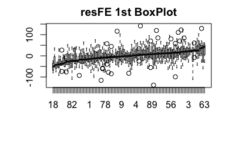

*construct the residual that utilizes the BLUPs for the random effects. Do it in these stages:* i) predict and save zeta0 * ii) predit and save eta0 * iii) generate a new residual, called resFE_RE which subtracts yhat, zeta0 and eta0 from the outcome *note: there is an easier way to get the residuals in this case, predict …, residuals, but we need to do it manually.

```r
idx.sch <- match(cc.data$schoolid, sort(unique(cc.data$schoolid)))
idx.cls <- match(cc.data$classid, sort(unique(cc.data$classid)))
```

```r
attach(cc.data)
ranefs <- ranef(fit1) #Pulling out the random effects
zeta0 <- ranefs$schoolid[, 1] #Random Intercept for School
eta0 <- ranefs$classid[, 1] #Random Intercept for Class
cc.data$zeta0 <- zeta0[idx.sch] # Putting Random Intercept of School back into the data set
cc.data$eta0 <- eta0[idx.cls] #Putting Random Intercept of Class back into the data set
resFE_RE <- math1st - pred.yhat - cc.data$zeta0 - cc.data$eta0
```

- show that these new residuals, resFE_RE are MUCH LESS (if not completely un-) correlated within school
- using the same method as before (boxplot?)

We expected a flatter residual line or something flat on 0 because the random effects as well as fixed were removed from the residuals. If we don’t have any additional model misspecification, we would have a flatter line or something close to it which is we see below.

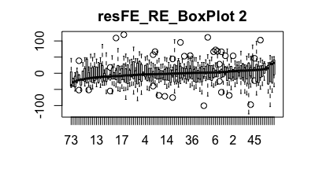

*examine the two sets of BLUPs (for random effects zeta0 and eta0) for normality* first ‘tag’ a single value from each grouping (e.g., school or classroom) so that you only have *as many BLUPs as the grouping factor (should be less of an issue in R)

If we examine the density and qqplot of the Zeta0 below, it’s close to symmetric, but with seeminlgy heavy tail on left. Since the sample size is 105, we can tolerate this lack of perfect and normality.

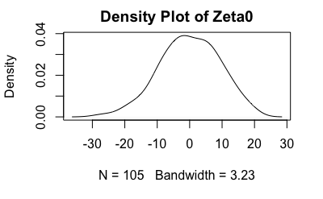

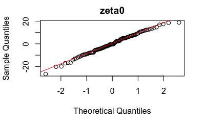

If we examine the density and qqplot of the eta0 below, it’s close to symmetric, and the tails look less heavy than the ones before. Since the sample size is 285, we think this is reasonable to accept it as normal.

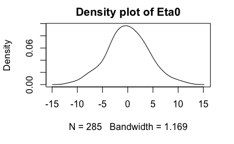

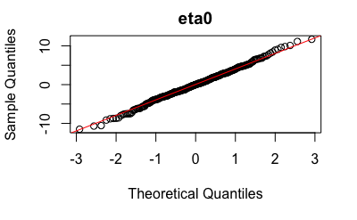

*now reload the data and fit a slightly more complicated model: use “classroom.dta” gen math1st = mathkind + mathgain

```r
dat <- read.csv("../classroom.csv")
dat$math1st <- dat$mathkind + dat$mathgain
dat <- dat[(complete.cases(dat)),]
attach(dat)
```

$$MATH1ST_{ijk} = b_0 + b_1HOUSEPOV_{k} + b_2YEARSTEA_{jk} + b_3MATHPREP_{jk} + b_4MATHKNOW_{jk} + b_5SES_{ijk} + b_6SEX_{ijk} + b_7MINORITY_{ijk} + \eta_{jk} + \zeta_{k} + \zeta_{1k}MINORITY_{ijk} + \varepsilon_{ijk}$$
With $\zeta_{k}$ ~ N(0,$\sigma^2_{\zeta_0}$), $\zeta_{1k}$ ~ N(0,$\sigma^2_{\zeta_1}$), $\eta_{jk}$ ~ N(0,$\sigma^2_{\eta}$), and $\varepsilon_{ijk}$ ~ N(0,$\sigma^2_{\varepsilon}$), BUT NOW $corr(\zeta_{0k},\zeta_{1k})$ = $\rho_{\zeta_{0}\zeta_{1}}$, which may not be zero, and all other pairs of random terms are independent of one another.

```r
M2 <- lmer(math1st ~ housepov + yearstea + mathprep + mathknow + ses + sex+ minority+ (minority|schoolid) + (1|classid))
print(summary(M2))
```

```
Linear mixed model fit by REML
t-tests use  Satterthwaite approximations to degrees of freedom ['lmerMod']
Formula: math1st ~ housepov + yearstea + mathprep + mathknow + ses + sex +      minority + (minority | schoolid) + (1 | classid)

REML criterion at convergence: 10717.5

Scaled residuals:
    Min      1Q  Median      3Q     Max
-3.8952 -0.6358 -0.0345  0.6129  3.6444

Random effects:
 Groups   Name        Variance Std.Dev. Corr
 classid  (Intercept)   86.69   9.311
 schoolid (Intercept)  381.20  19.524
          minority     343.13  18.524   -0.83
 Residual             1039.39  32.240
Number of obs: 1081, groups:  classid, 285; schoolid, 105

Fixed effects:
              Estimate Std. Error         df t value Pr(>|t|)
(Intercept)  5.395e+02  5.655e+00  1.731e+02  95.399  < 2e-16 ***
housepov    -1.606e+01  1.257e+01  1.000e+02  -1.277    0.204
yearstea    -4.368e-03  1.376e-01  2.172e+02  -0.032    0.975
mathprep    -2.918e-01  1.335e+00  1.981e+02  -0.218    0.827
mathknow     1.632e+00  1.359e+00  2.248e+02   1.201    0.231
ses          9.431e+00  1.543e+00  1.063e+03   6.111 1.39e-09 ***
sex         -8.628e-01  2.084e+00  1.022e+03  -0.414    0.679
minority    -1.638e+01  3.896e+00  5.820e+01  -4.203 9.17e-05 ***
---
Signif. codes:  0 ‘***’ 0.001 ‘**’ 0.01 ‘*’ 0.05 ‘.’ 0.1 ‘ ’ 1

Correlation of Fixed Effects:
         (Intr) houspv yearst mthprp mthknw ses    sex
housepov -0.394
yearstea -0.253  0.091
mathprep -0.576  0.037 -0.167
mathknow -0.078  0.061  0.024 -0.002
ses      -0.105  0.089 -0.021  0.052 -0.005
sex      -0.172 -0.013  0.014 -0.005  0.010  0.024
minority -0.494 -0.157  0.027 -0.002  0.099  0.113 -0.014
```

```r
idx.sch <- match(dat$schoolid, sort(unique(dat$schoolid)))
idx.cls <- match(dat$classid, sort(unique(dat$classid)))
```

*manually construct the residual that removes only the ‘fixed effects’, call this residual: resFE

```r
pred.yhat.2 <- predict(M2, re.form = ~0)
resFE.2 <- dat$math1st - pred.yhat.2
```

Below, we have sorted each of the fixed effect residuals for the schools by their median from lowest to highest. If we are assuming independence of residuals within schools, then, we would expect to see a flat-line showing that residuals across schools is random. However, since we are seeing a positive trending line, we can conclude that residuals are not random and it appears to be dependent on school like the results of the less complicated model above.

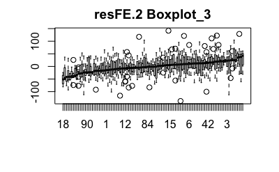

*construct the residual that utilizes the BLUPs for the random effects. Do it in these stages:* i) predict and save zeta0 AND zeta1 (you need to give them in reverse order in STATA - ask me why if you want) * ii) predit and save eta0 * iii) generate a new residual, called resFE_RE which subtracts yhat, zeta0, MINORITY*zeta1 and eta0

```r
ranerr <- ranef(M2)
zeta0 <- ranerr$schoolid[,1]
zeta1 <- ranerr$schoolid[,2] #It is the random slope of the minority intercept
eta0 <- ranerr$classid[,1] #This is the random intercept for the classroom level.
dat$zeta0 <- zeta0[idx.sch]
dat$zeta1 <- zeta1[idx.sch]
dat$eta0 <- eta0[idx.cls]
resFE_RE.2 <- dat$math1st - (pred.yhat.2 + dat$zeta0 + (dat$minority * dat$zeta1) + dat$eta0)#This accounts for removing both fixed and random effects and the random effects are removed manually. Therefore, residuals should be less dependent than the previous one. Thus, we expect to see a flatter line.
```

- show that these new residuals, resFE_RE are MUCH LESS (if not completely un-) correlated within school
- using the same method as before (boxplot?)

We expected a flatter residual line or something flat on 0 because the random effects as well as fixed were removed from the residuals. Additonally, the model also incorporates a correlated random effect on minority at the school level so, we are expecting a much flatter line than the less complicated model before as our total variance explained in this model is higher.

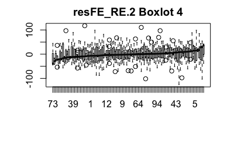

*examine the three sets of BLUPs (for random effects zeta0 and eta0) for normality

If we examine the density and qqplot of the Zeta0 BLUP below, it’s not that close to symmetric, and heavy tails on both ends. Even though the sample size is 105, we find it hard to tolerate this lack of normality.

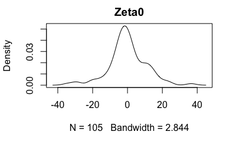

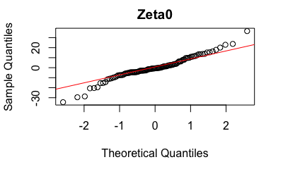

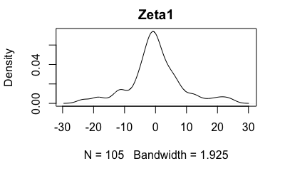

If we examine the density and qqplot of the Zeta1 BLUP below, it’s not that close to symmetric, and heavy tails on both ends. Even though the sample size is 105, we find it hard to tolerate this lack of normality.

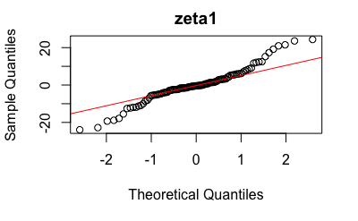

If we examine the density and qqplot of the eta0 below, it’s close to symmetric, and the tails look less heavy than the ones before. Since the sample size is 285, we think this is reasonable to accept it as normal.

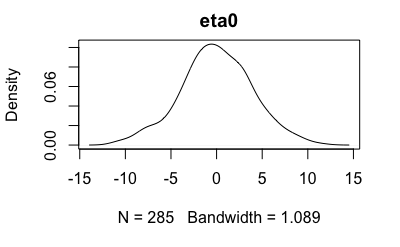

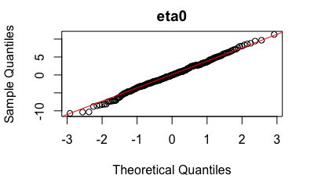

*plot zeta0 vs. zeta1 to see whether the estimated correlation is consistent with the observed.* Use tag to subset as before

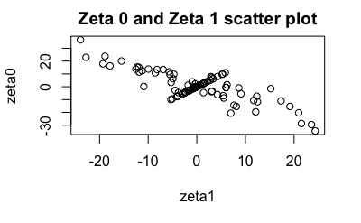